# ANOVA Lab

```r
library(ggplot2)
library(dplyr)

theme_set(theme_bw())

## Better histograms
gh <- function(bins = 10) {
  geom_histogram(color = 'black', fill = 'gray80', bins = bins)
}
```

## Introduction

This lab is oriented around the use of the `aov()` function in R to fit an analysis of variance model.

## One-way ANOVA

The first ANOVA we will consider is that which compares equality of means across several groups. To begin, we’ll consider the `dog` dataset that was introduced in class.

```r
dogs <- read.csv("https://collinn.github.io/data/dogs.csv")
```

From this dataset, we find that we have one quantitative variable (speed), along with three categorical variables for breed, size, and color. We can quickly get a summary of these categories with the table function

```r
with(dogs, table(color))
```

```
## color
##  black  brown  white yellow
##    200     50     50    100
```

Here, we see that the color variable has 4 categories with 400 observations. To conduct an ANOVA, we will use the same formula syntax that was used for the two sample t-test, with our quantitative variable on the left hand side and the categories on the right. We’ll do this using `aov()`

```r
aov(speed ~ color, dogs)
```

```
## Call:
##    aov(formula = speed ~ color, data = dogs)
##
## Terms:
##                    color Residuals
## Sum of Squares   1651.64  50746.34
## Deg. of Freedom        3       396
##
## Residual standard error: 11.32022
## Estimated effects may be unbalanced
```

The basic output of this function only gives us limited information related to the sums of squares and degrees of freedom. We can recreate the tables we saw in lecture by passing the output of `aov()` into a `summary()` function, either with a pipe (`%>%`) or by assigning the output to a new variable and calling summary on it

```r
## Method 1
# model <- aov(speed ~ color, dogs)
# summary(model)

## Method 2
aov(speed ~ color, dogs) %>% summary()
```

```
##              Df Sum Sq Mean Sq F value  Pr(>F)
## color         3   1652   550.5   4.296 0.00533 **
## Residuals   396  50746   128.1
## ---
## Signif. codes:  0 '***' 0.001 '**' 0.01 '*' 0.05 '.' 0.1 ' ' 1
```

Here, we now get the mean sums of squares for our groups and residuals, along with an F statistic and an associated p-value. In particular, we know that this statistic follows an F distribution with $F(3, 396)$ degrees of freedom. The $p$-value would be the area under the curve to the right of the red line below:

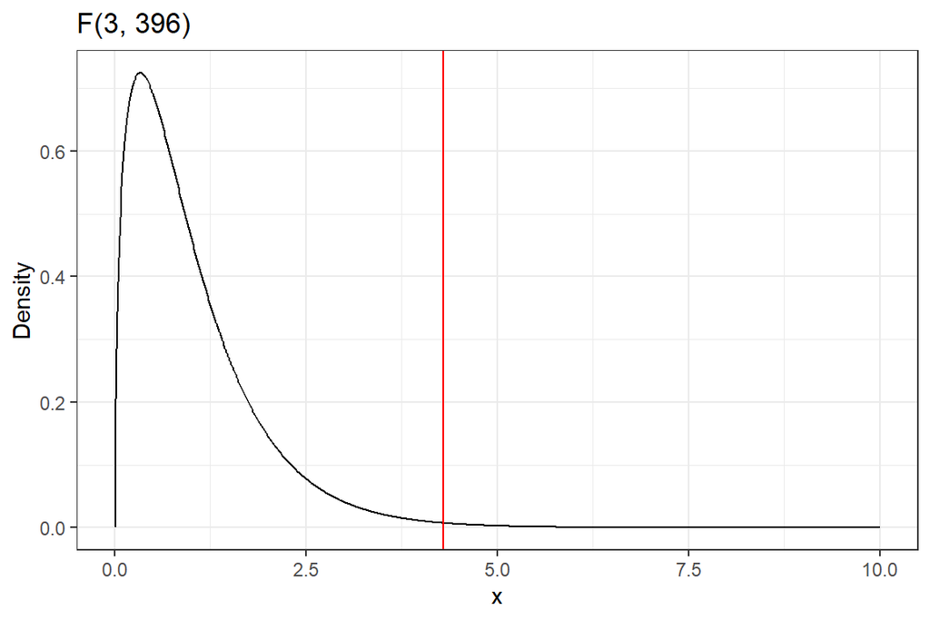

**Question 1:** Using the `dogs` dataset, recreate a boxplot showing the speeds of each dog, separated by color. Based on this plot, does it appear as if there is a statistically significant ($\alpha = 0.05$) difference in group means? Compare your conclusion with the ANOVA output done above. Explain what might be causing you to reject the null hypothesis in this case.

**Question 2:** The data for this question involves sandwiches and ants. An experiment was conducted in which sandwiches were made with various combinations of filling and bread, both with and without butter added. A piece of the sandwich was ripped off and left near an ant hill for several minutes, at which point a jar was placed over the sandwich and the number of ants surrounding it were counted.

```r
sandwich <- read.csv("https://collinn.github.io/data/sandwich.csv")
```

Suppose that you wanted to choose one variable (Butter or Filling) to predict how many ants will be attracted to a sandwich. Which do you think would best accomplish this goal? Justify your answer with a plot and a statistical test.

## Post-Hoc Testing

As noted previously, ANOVA is specifically concerned with testing the null hypothesis of equality between means for multiple groups,

$$H_0: \mu_1 = \mu_2 = \dots = \mu_k$$
Should we perform an ANOVA and *reject* our null hypothesis, we only know that *at least* two of our group means are different. *Post-hoc* pairwise testing (Latin for “after this” or “after the fact”) can be done to determine which of our pairwise differences are likely responsible.

Consider again our dog dataset in which we wish to test for equality in average speed between different colored dogs. This is done simply with the `aov()` function

```r
## This will assign the results to a variable called model
model <- aov(speed ~ color, dogs)
summary(model)
```

```
##              Df Sum Sq Mean Sq F value  Pr(>F)
## color         3   1652   550.5   4.296 0.00533 **
## Residuals   396  50746   128.1
## ---
## Signif. codes:  0 '***' 0.001 '**' 0.01 '*' 0.05 '.' 0.1 ' ' 1
```

Here, we see information on the squared error from the grouping and our residuals, along with an F-statistic and a p-value. If we were testing at the $\alpha = 0.05$ level, we would reject this test as $p-val = 0.0053$.

To determine which pairwise colors had a difference, we can use the `TukeyHSD()` function (Tukey honest statistical difference) on the `model` object we created above:

```r
## Pass in output from aov() function
comp <- TukeyHSD(model)
comp
```

```
##   Tukey multiple comparisons of means
##     95% family-wise confidence level
##
## Fit: aov(formula = speed ~ color, data = dogs)
##
## $color
##                   diff         lwr        upr     p adj
## brown-black   1.961210  -2.6566404  6.5790606 0.6923676
## white-black   4.236027  -0.3818238  8.8538772 0.0852883
## yellow-black -2.396760  -5.9737312  1.1802120 0.3101186
## white-brown   2.274817  -3.5663536  8.1159868 0.7467192
## yellow-brown -4.357970  -9.4165715  0.7006321 0.1188852
## yellow-white -6.632786 -11.6913881 -1.5741845 0.0043711
```

From this output, we see the only statistically significant difference in between yellow and white.

Finally, we can plot the output from the `TukeyHSD()` function with a call to the base R function `plot()`

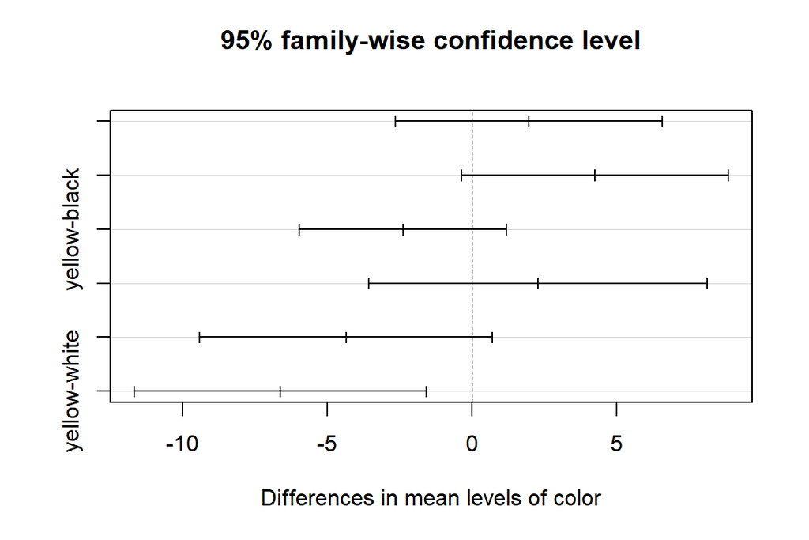

```r
## Pass in output from TukeyHSD() function
plot(comp)
```

Note here again, the only confidence interval that does not contain 0 (our null hypothesis for pairwise tests) is that between yellow and white, consistent with the output we observed above.

**Question 3:** An individual’s “critical clicker frequency” is the highest frequency at which a flickering light source can actually be detected to be flickering; at frequencies above this rate, the light source will appear continuous. **EPILEPSY WARNING** (An example of this can be seen [here](https://youtu.be/xW3oQUe6DEw))

The data below come from a study titled “The effect of iris color on critical flicker frequency” published in the *Journal of General Psychology*, recording the critical clicker frequency and iris color for $n = 19$ subjects

```r
flicker <- read.delim('https://raw.githubusercontent.com/IowaBiostat/data-sets/main/flicker/flicker.txt')
```

- **Part A:** What are the null and alternative hypotheses for one-way ANOVA analyzing this data
- **Part B:** Use the `aov()` function to analyze this data and print a summary using `summary()`
- **Part C:** Does Color or the Residuals have a larger sum of squares? Which has a larger mean square? What accounts for this discrepancy?
- **Part D:** Perform post-hoc testing to determine which pairwise groups have a statistically significant difference between them.
- **Part E:** Of the groups you found to have statistically significant difference in means in Part D, which group appears to have the *larger* mean?

# More on F-tests

The following code simulations a few situations to help us better understand what some components of the ANOVA table represent. We are going to also see what changing group variances does to the F-statistic and p-value for the ANOVA test.

### Simulated Groups with Large Variances

Here we are simulating 50 observations from each of 3 groups. All have the same population std. dev. $\sigma=40$. The corresponding population means are $\mu_1 = 250$, $\mu_1 = 245$, and $\mu_1 = 255$. The group means are not equal, but the variances are relatively large which we can see by the following plot.

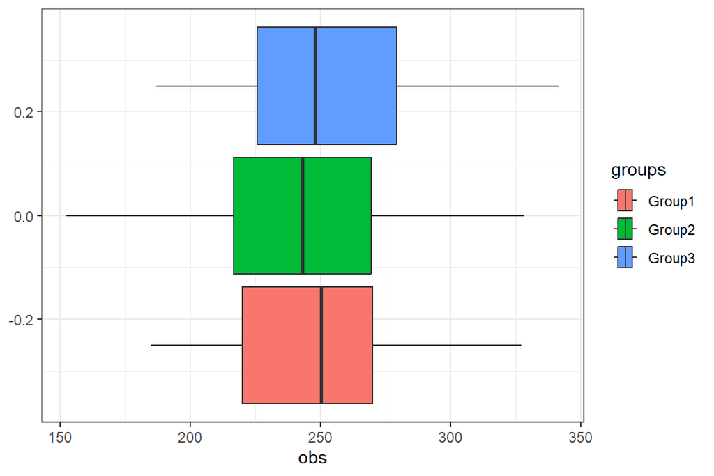

```r
set.seed(423)
group1 = rnorm(50, mean=250, sd=40)
group2 = rnorm(50, mean=245, sd=40)
group3 = rnorm(50, mean=255, sd=40)
groups = c(rep("Group1",50), rep("Group2", 50), rep("Group3", 50))

data=data.frame(c(group1, group2, group3),groups)
colnames(data)=c("obs","groups")

ggplot(data, aes(x=obs, fill=groups)) + geom_boxplot()
```

```r
# sample group means
mean(group1); mean(group2); mean(group3)
```

```
## [1] 250.4002
```

```
## [1] 242.5958
```

```
## [1] 249.6252
```

**Question 4**: Think about how much variability there is *within* each group, i.e., how much observations vary from each other within group 1, withing group 2, and within group 3 respectively. Are the differences in group means large or small relative to how much variability there is *within* groups. Explain.

**Question 5**: Utilizing your answer from Question 4, do you think the F-statistic from an ANOVA test will give us a large or small p-value for testing if these means are different? Explain. Check your answer using the `aov()` and `summary` functions with the `data` object.

### Simulated Groups with Small Variances

We are going to do the same thing as above, but with smaller variances.

We are simulating 50 observations from each of 3 groups. All have the same population std. dev. $\sigma=4$. The corresponding population means are $\mu_1 = 250$, $\mu_1 = 245$, and $\mu_1 = 255$.

**Note:** The means haven’t changed from the last example, only the variances. Let’s see how that affects the ANOVA test.

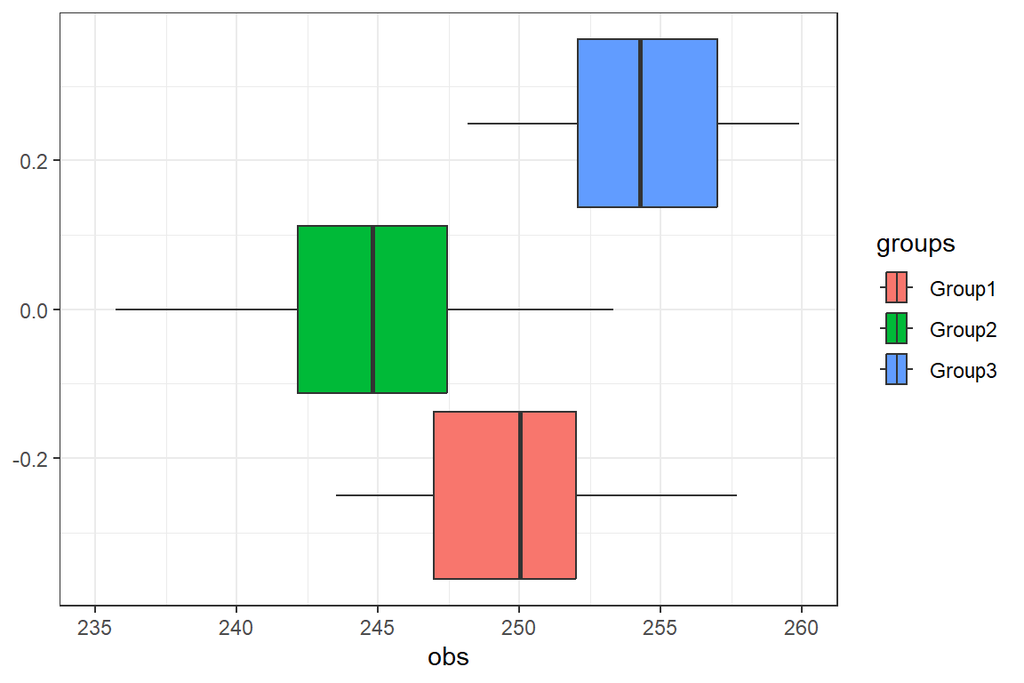

```r
set.seed(423)
group1 = rnorm(50, mean=250, sd=4)
group2 = rnorm(50, mean=245, sd=4)
group3 = rnorm(50, mean=255, sd=4)
groups = c(rep("Group1",50), rep("Group2", 50), rep("Group3", 50))

data2=data.frame(c(group1, group2, group3),groups)
colnames(data2)=c("obs","groups")

ggplot(data2, aes(x=obs, fill=groups)) + geom_boxplot() +
  xlim(235, 260)
```

```r
# sample group means
mean(group1); mean(group2); mean(group3)
```

```
## [1] 250.04
```

```
## [1] 244.7596
```

```
## [1] 254.4625
```

**Question 6**: Think about how much variability there is *within* each group for this example. Are the differences in group means large or small relative to how much variability there is *within* groups. Explain. Is it easier to see differences in the groups compared to the previous example?

**Question 7**: Do you think the F-statistic from an ANOVA test will be larger or smaller than the previous example? Check your answer using the `aov()` and `summary` functions with the `data2` object.

**Question 8**: In the ANOVA output for Question 7, which Sum of Squares corresponds to *within* group variability? How does this Sum of Squares compare for the 2 different scenarios we just looked at?

### Affect of Axis scale on how we perceive differences

The following plot uses the `data2` simulated data from above. The only difference is that I have changed the x-axis scale.

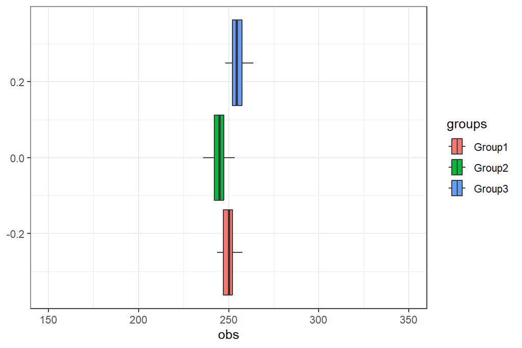

```r
ggplot(data2, aes(x=obs, fill=groups)) + geom_boxplot() +
  xlim(150, 350)
```

**Question 9**: Does this change your answer to whether or not you can visually tell the groups apart? Did it become more difficult?

The fact that changing the scale can affect how we perceive whether the groups are different means we should be wary of just visually looking at graphs to determine differences. The F-test circumvents this by comparing how different the group means are relative to how ‘wide’ the distributions are (variability within groups) so that we are not lead astray by our eyes.